# Pleural proteomics of pleural infection

Results from Olink Target 96 Inflammation panel

Paul Yousefi

29 October 2026

# Protein measurements

Of the **pleural** samples run, 254 passed the default qc performed in the `metaboprep` package and instituted by the lab.

For the moment, all 92 measured proteins have been retained for analysis.

See pleuralmetaboprep_qc_report.html for full details.

# Population description

## Sample characteristics table

|  | level | Overall |
| --- | --- | --- |
| n |  | 254 |
| age (mean (SD)) |  | 67.26 (16.07) |
| female (%) | 0 | 170 (66.9) |
|  | 1 | 84 (33.1) |
| plate (%) | GB390725-RB_1 | 82 (32.3) |
|  | GB390725-RB_2 | 87 (34.3) |
|  | GB390725-RB_3 | 85 (33.5) |
| infect.fct (%) | control | 30 (21.3) |
|  | inter | 44 (31.2) |
|  | case | 67 (47.5) |
| infect.num (%) | 1 | 30 (21.3) |
|  | 2 | 44 (31.2) |
|  | 3 | 67 (47.5) |
| infect.bi (%) | 0 | 74 (52.5) |
|  | 1 | 67 (47.5) |
| comp.out (%) | 0 | 89 (63.1) |
|  | 1 | 52 (36.9) |
| infect.bi.new (%) | 0 | 114 (63.0) |
|  | 1 | 67 (37.0) |
| final.diagnosis.1 (%) | M/breast | 5 (2.0) |
|  | M/colorectal | 2 (0.8) |
|  | M/haem | 4 (1.6) |
|  | M/lung/adeno | 7 (2.8) |
|  | M/lung/small | 1 (0.4) |
|  | M/lung/squamous | 1 (0.4) |
|  | M/lung/unsclc | 1 (0.4) |
|  | M/lung/x | 3 (1.2) |
|  | M/meso/biphasic | 1 (0.4) |
|  | M/meso/desmoplastic | 1 (0.4) |
|  | M/meso/epithelioid | 12 (4.7) |
|  | M/meso/sarcomatoid | 6 (2.4) |
|  | M/meso/x | 1 (0.4) |
|  | M/Mullerian | 2 (0.8) |
|  | M/oesophageal | 2 (0.8) |
|  | M/ovarian | 1 (0.4) |
|  | M/renal | 2 (0.8) |
|  | M/sarcoma | 2 (0.8) |
|  | M/skin | 2 (0.8) |
|  | M/UGI | 2 (0.8) |
|  | X/cardiac/u | 14 (5.5) |
|  | X/hepatic/u | 13 (5.1) |
|  | X/infection/bacterial | 22 (8.7) |
|  | X/infection/CPPE | 44 (17.3) |
|  | X/infection/SPE | 30 (11.8) |
|  | X/infection/utrue | 45 (17.7) |
|  | X/inflam/BAPE | 14 (5.5) |
|  | X/inflam/viral | 1 (0.4) |
|  | X/renal/u | 13 (5.1) |

## Variable definitions

### infection

`final.diagnosis.1` was used to derive the infection status variables begining with `infect`.

`infect.fct` and `infect.num` are identical 3-level variables, except the first is formatted as factor while the second is formatted as numeric.

The levels of these variables are defined as follows:

1. Control: `final.diagnosis.1`= “SPE”
2. Inter: `final.diagnosis.1` = “CPPE”
3. Case: `final.diagnosis.1`= “utrue” or `final.diagnosis.1`= “bacterial”

`infect.bi` is just the cases from above i.e. `infect.num` >2

`infect.bi.new` is `infect.bi` with N= 40 additional controls included who had `final.diagnosis.1` values equal to “X/renal/u”, “X/hepatic/u”, or “X/cardiac/u”.

### comp out

`comp.out` is a variable I received with the title: “composite.outcome..lytics..surgery.or..3m.mortality”

# Protein-wide associations

Phenotypic characteristics of participants described in Phenotype information were examined for association with protein abundances (Protein measurements)

## Models

The formulae of linear models examined are shown in the table below:

```
> $pleural.infect.fct
> methylation ~ infect.fct
> <environment: 0x55643e5ebe60>
>
> $pleural.infect.num
> methylation ~ infect.num
> <environment: 0x55643e5fa0b0>
>
> $pleural.infect.bi
> methylation ~ infect.bi
> <environment: 0x55643e6dfcb8>
>
> $pleural.comp.out
> methylation ~ comp.out
> <environment: 0x55643e6e2e80>
>
> $pleural.infect.bi.new
> methylation ~ infect.bi.new
> <environment: 0x55643e6ebd98>
>
> $pleural.female
> methylation ~ female
> <environment: 0x55643e6eef60>
>
> $pleural.age
> methylation ~ age
> <environment: 0x55643e6f7e78>
>
> $pleural.infect.fct.plate
> methylation ~ infect.fct + plate
> <environment: 0x55643e6fb040>
>
> $pleural.infect.num.plate
> methylation ~ infect.num + plate
> <environment: 0x55643e6fe0b8>
>
> $pleural.infect.bi.plate
> methylation ~ infect.bi + plate
> <environment: 0x55643e704f60>
>
```

[output cut: 20 more lines]

```
> $pleural.infect.num.fulladj
> methylation ~ infect.num + female + age + plate
> <environment: 0x55643e726860>
>
> $pleural.infect.bi.fulladj
> methylation ~ infect.bi + female + age + plate
> <environment: 0x55643e72b558>
>
> $pleural.comp.out.fulladj
> methylation ~ comp.out + female + age + plate
> <environment: 0x55643e732160>
>
> $pleural.infect.bi.new.fulladj
> methylation ~ infect.bi.new + female + age + plate
> <environment: 0x55643e734f38>
```

## Count of significant hits

Number of significant hits identified per model. Statistical significance was determined using a Bonferroni multiple testing threshold correcting for 92 tests. That is 0.05/ 92 = 5.43e-04

| model | n.bonf.sig | n.fdr.sig |
| --- | --- | --- |
| pleural.infect.fct | 28 | 34 |
| pleural.infect.num | 31 | 39 |
| pleural.infect.bi | 30 | 38 |
| pleural.comp.out | 21 | 33 |
| pleural.infect.bi.new | 32 | 48 |
| pleural.female | 2 | 6 |
| pleural.age | 20 | 34 |
| pleural.infect.fct.plate | 28 | 34 |
| pleural.infect.num.plate | 31 | 39 |
| pleural.infect.bi.plate | 30 | 38 |
| pleural.comp.out.plate | 22 | 33 |
| pleural.infect.bi.new.plate | 32 | 47 |
| pleural.female.plate | 3 | 6 |
| pleural.age.plate | 21 | 34 |
| pleural.infect.fct.fulladj | 27 | 35 |
| pleural.infect.num.fulladj | 28 | 35 |
| pleural.infect.bi.fulladj | 26 | 35 |
| pleural.comp.out.fulladj | 20 | 30 |
| pleural.infect.bi.new.fulladj | 32 | 45 |

## All models

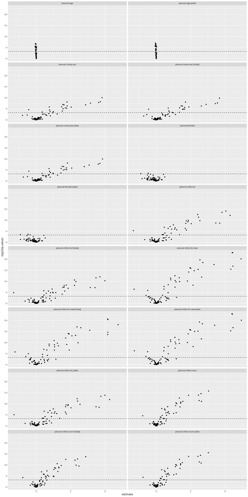

## Main models with annotated hits

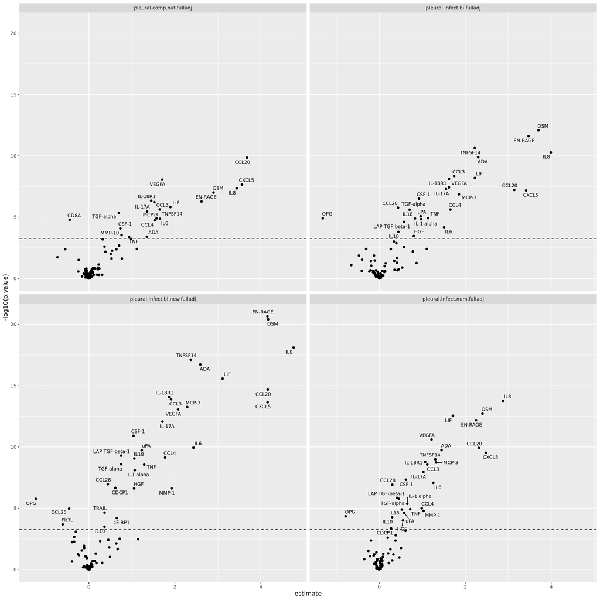

## Top hits

Results of all Bonferroni-significant hits for main models:

$pleural.infect.num.fulladj

| gene | n | estimate | se | p.value | p.adjust |
| --- | --- | --- | --- | --- | --- |
| IL8 | 141 | 2.88 | 0.33 | 1.7e-14 | 1.6e-12 |
| OSM | 141 | 2.40 | 0.29 | 1.9e-13 | 1.8e-11 |
| LIF | 141 | 1.71 | 0.21 | 2.9e-13 | 2.7e-11 |
| EN-RAGE | 141 | 2.25 | 0.28 | 6.5e-13 | 6.0e-11 |
| VEGFA | 141 | 1.22 | 0.17 | 2.5e-11 | 2.3e-09 |
| CCL20 | 141 | 2.32 | 0.33 | 1.2e-10 | 1.1e-08 |
| ADA | 141 | 1.45 | 0.21 | 1.8e-10 | 1.7e-08 |
| CXCL5 | 141 | 2.48 | 0.36 | 3.0e-10 | 2.7e-08 |
| TNFSF14 | 141 | 1.31 | 0.20 | 1.0e-09 | 9.3e-08 |
| IL-18R1 | 141 | 1.07 | 0.17 | 1.6e-09 | 1.5e-07 |
| MCP-3 | 141 | 1.32 | 0.20 | 1.8e-09 | 1.7e-07 |
| CCL3 | 141 | 1.12 | 0.18 | 2.7e-09 | 2.5e-07 |
| IL-17A | 141 | 1.03 | 0.17 | 1.1e-08 | 1.0e-06 |
| CSF-1 | 141 | 0.62 | 0.11 | 4.7e-08 | 4.4e-06 |
| IL6 | 141 | 1.26 | 0.22 | 8.4e-08 | 7.7e-06 |
| CCL28 | 141 | 0.30 | 0.05 | 1.2e-07 | 1.1e-05 |
| LAP TGF-beta-1 | 141 | 0.42 | 0.08 | 1.4e-06 | 1.3e-04 |
| TGF-alpha | 141 | 0.46 | 0.09 | 1.7e-06 | 1.6e-04 |
| IL-1 alpha | 141 | 0.65 | 0.14 | 4.3e-06 | 4.0e-04 |
| CCL4 | 141 | 0.99 | 0.22 | 9.9e-06 | 9.1e-04 |
| TNF | 141 | 0.72 | 0.16 | 1.2e-05 | 1.1e-03 |
| IL18 | 141 | 0.53 | 0.12 | 1.3e-05 | 1.2e-03 |
| MMP-1 | 141 | 1.03 | 0.23 | 1.6e-05 | 1.5e-03 |
| uPA | 141 | 0.58 | 0.13 | 2.4e-05 | 2.2e-03 |
| OPG | 141 | -0.78 | 0.19 | 4.5e-05 | 4.2e-03 |
| IL10 | 141 | 0.30 | 0.07 | 5.3e-05 | 4.9e-03 |
| HGF | 141 | 0.55 | 0.14 | 9.7e-05 | 9.0e-03 |
| CDCP1 | 141 | 0.28 | 0.08 | 4.4e-04 | 4.0e-02 |

$pleural.infect.bi.fulladj

| gene | n | estimate | se | p.value | p.adjust |
| --- | --- | --- | --- | --- | --- |
| OSM | 141 | 3.70 | 0.47 | 8.3e-13 | 7.7e-11 |
| EN-RAGE | 141 | 3.47 | 0.45 | 2.4e-12 | 2.3e-10 |
| TNFSF14 | 141 | 2.22 | 0.30 | 2.3e-11 | 2.2e-09 |
| IL8 | 141 | 3.99 | 0.56 | 5.2e-11 | 4.8e-09 |
| ADA | 141 | 2.30 | 0.33 | 1.3e-10 | 1.2e-08 |
| CCL3 | 141 | 1.74 | 0.28 | 4.4e-09 | 4.1e-07 |
| LIF | 141 | 2.23 | 0.36 | 6.3e-09 | 5.8e-07 |
| IL-18R1 | 141 | 1.62 | 0.26 | 7.6e-09 | 7.0e-07 |
| VEGFA | 141 | 1.62 | 0.28 | 3.7e-08 | 3.4e-06 |
| IL-17A | 141 | 1.55 | 0.27 | 5.1e-08 | 4.7e-06 |
| CCL20 | 141 | 3.14 | 0.55 | 6.0e-08 | 5.6e-06 |
| CXCL5 | 141 | 3.42 | 0.60 | 6.7e-08 | 6.1e-06 |
| MCP-3 | 141 | 1.85 | 0.33 | 1.4e-07 | 1.3e-05 |
| CSF-1 | 141 | 0.92 | 0.17 | 3.1e-07 | 2.9e-05 |
| CCL28 | 141 | 0.44 | 0.09 | 1.7e-06 | 1.6e-04 |
| CCL4 | 141 | 1.66 | 0.34 | 2.4e-06 | 2.2e-04 |
| TGF-alpha | 141 | 0.71 | 0.14 | 2.5e-06 | 2.3e-04 |
| uPA | 141 | 0.96 | 0.21 | 8.5e-06 | 7.8e-04 |
| TNF | 141 | 1.14 | 0.25 | 1.2e-05 | 1.1e-03 |
| OPG | 141 | -1.31 | 0.29 | 1.2e-05 | 1.1e-03 |
| IL18 | 141 | 0.83 | 0.18 | 1.3e-05 | 1.2e-03 |
| IL-1 alpha | 141 | 0.98 | 0.22 | 1.4e-05 | 1.3e-03 |
| LAP TGF-beta-1 | 141 | 0.58 | 0.13 | 2.5e-05 | 2.3e-03 |
| IL6 | 141 | 1.51 | 0.37 | 6.6e-05 | 6.1e-03 |
| IL10 | 141 | 0.45 | 0.11 | 1.6e-04 | 1.5e-02 |
| HGF | 141 | 0.80 | 0.22 | 3.4e-04 | 3.2e-02 |

$pleural.comp.out.fulladj

| gene | n | estimate | se | p.value | p.adjust |
| --- | --- | --- | --- | --- | --- |
| CCL20 | 141 | 3.68 | 0.53 | 1.4e-10 | 1.3e-08 |
| VEGFA | 141 | 1.70 | 0.28 | 8.8e-09 | 8.1e-07 |
| CXCL5 | 141 | 3.56 | 0.60 | 2.2e-08 | 2.0e-06 |
| IL8 | 141 | 3.44 | 0.59 | 4.4e-08 | 4.1e-06 |
| OSM | 141 | 2.90 | 0.51 | 9.8e-08 | 9.0e-06 |
| IL-18R1 | 141 | 1.45 | 0.27 | 4.5e-07 | 4.2e-05 |
| EN-RAGE | 141 | 2.62 | 0.50 | 5.3e-07 | 4.9e-05 |
| CCL3 | 141 | 1.52 | 0.29 | 5.9e-07 | 5.5e-05 |
| LIF | 141 | 1.90 | 0.38 | 1.5e-06 | 1.4e-04 |
| TNFSF14 | 141 | 1.65 | 0.33 | 2.3e-06 | 2.1e-04 |
| IL-17A | 141 | 1.35 | 0.28 | 3.4e-06 | 3.2e-04 |
| TGF-alpha | 141 | 0.70 | 0.15 | 4.5e-06 | 4.1e-04 |
| MCP-3 | 141 | 1.58 | 0.35 | 1.3e-05 | 1.2e-03 |
| IL6 | 141 | 1.65 | 0.37 | 1.4e-05 | 1.3e-03 |
| CD8A | 141 | -0.45 | 0.10 | 1.7e-05 | 1.5e-03 |
| CCL4 | 141 | 1.53 | 0.34 | 1.8e-05 | 1.7e-03 |
| CSF-1 | 141 | 0.73 | 0.18 | 8.3e-05 | 7.6e-03 |
| MMP-10 | 141 | 0.76 | 0.20 | 2.9e-04 | 2.6e-02 |
| ADA | 141 | 1.35 | 0.37 | 4.0e-04 | 3.6e-02 |
| TNF | 141 | 0.94 | 0.26 | 4.2e-04 | 3.9e-02 |

$pleural.infect.bi.new.fulladj

| gene | n | estimate | se | p.value | p.adjust |
| --- | --- | --- | --- | --- | --- |
| EN-RAGE | 181 | 4.15 | 0.38 | 2.2e-21 | 2.0e-19 |
| OSM | 181 | 4.17 | 0.39 | 3.9e-21 | 3.6e-19 |
| IL8 | 181 | 4.76 | 0.48 | 7.8e-19 | 7.2e-17 |
| TNFSF14 | 181 | 2.37 | 0.25 | 7.7e-18 | 7.1e-16 |
| ADA | 181 | 2.59 | 0.27 | 1.9e-17 | 1.7e-15 |
| LIF | 181 | 3.11 | 0.34 | 2.7e-16 | 2.5e-14 |
| CCL20 | 181 | 4.16 | 0.48 | 2.1e-15 | 1.9e-13 |
| IL-18R1 | 181 | 1.86 | 0.22 | 8.6e-15 | 7.9e-13 |
| CCL3 | 181 | 1.91 | 0.23 | 1.3e-14 | 1.2e-12 |
| CXCL5 | 181 | 4.16 | 0.50 | 2.2e-14 | 2.1e-12 |
| MCP-3 | 181 | 2.29 | 0.28 | 5.5e-14 | 5.1e-12 |
| VEGFA | 181 | 2.07 | 0.26 | 8.7e-14 | 8.0e-12 |
| IL-17A | 181 | 1.71 | 0.22 | 8.5e-13 | 7.9e-11 |
| CSF-1 | 181 | 1.04 | 0.14 | 1.2e-11 | 1.1e-09 |
| IL6 | 181 | 2.43 | 0.35 | 1.2e-10 | 1.1e-08 |
| uPA | 181 | 1.23 | 0.18 | 1.8e-10 | 1.7e-08 |
| LAP TGF-beta-1 | 181 | 0.75 | 0.11 | 5.1e-10 | 4.7e-08 |
| CCL4 | 181 | 1.77 | 0.27 | 7.3e-10 | 6.7e-08 |
| IL18 | 181 | 1.06 | 0.16 | 8.8e-10 | 8.1e-08 |
| TGF-alpha | 181 | 0.75 | 0.12 | 2.6e-09 | 2.4e-07 |
| TNF | 181 | 1.29 | 0.21 | 2.8e-09 | 2.6e-07 |
| IL-1 alpha | 181 | 1.07 | 0.18 | 7.8e-09 | 7.1e-07 |
| CCL28 | 181 | 0.44 | 0.08 | 1.1e-07 | 1.0e-05 |
| CDCP1 | 181 | 0.62 | 0.11 | 2.2e-07 | 2.0e-05 |
| MMP-1 | 181 | 1.92 | 0.36 | 2.4e-07 | 2.2e-05 |
| HGF | 181 | 1.05 | 0.20 | 2.4e-07 | 2.2e-05 |
| OPG | 181 | -1.24 | 0.25 | 1.7e-06 | 1.6e-04 |
| CCL25 | 181 | -0.46 | 0.10 | 1.1e-05 | 9.9e-04 |
| TRAIL | 181 | 0.37 | 0.08 | 2.3e-05 | 2.1e-03 |
| 4E-BP1 | 181 | 0.65 | 0.16 | 6.2e-05 | 5.7e-03 |
| Flt3L | 181 | -0.61 | 0.16 | 2.0e-04 | 1.9e-02 |
| IL10 | 181 | 0.36 | 0.10 | 3.2e-04 | 2.9e-02 |

## QQ plots

```
> $pleural.infect.fct
```

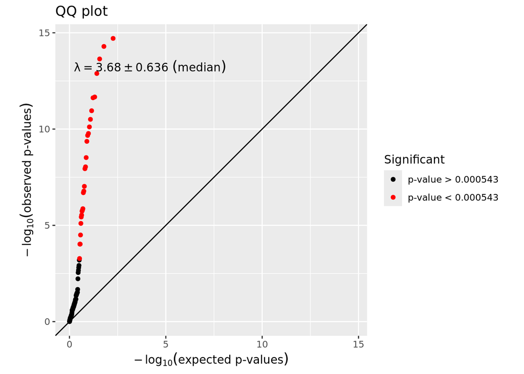

```
>
> $pleural.infect.num
```

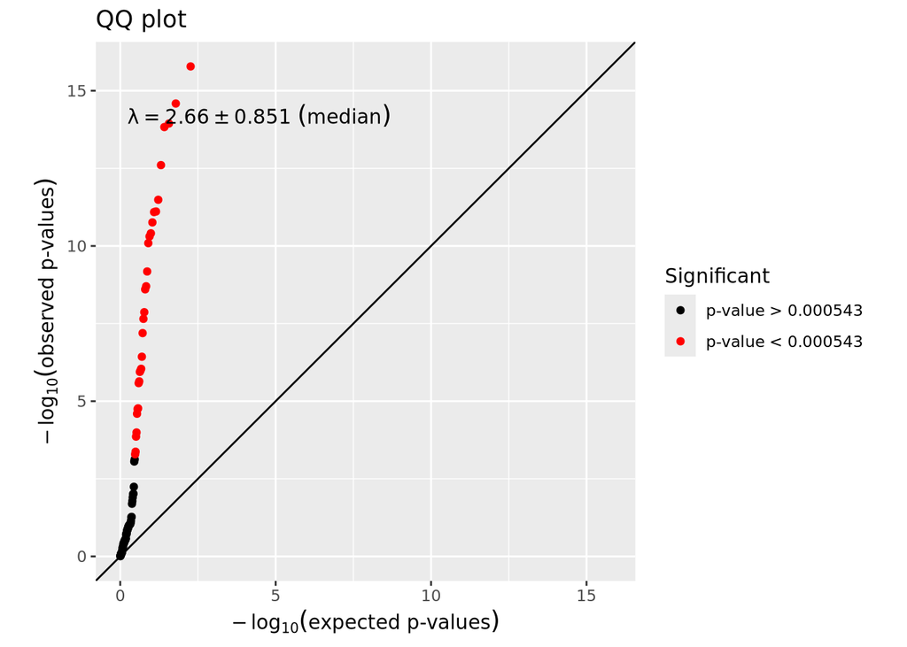

```
>
> $pleural.infect.bi
```

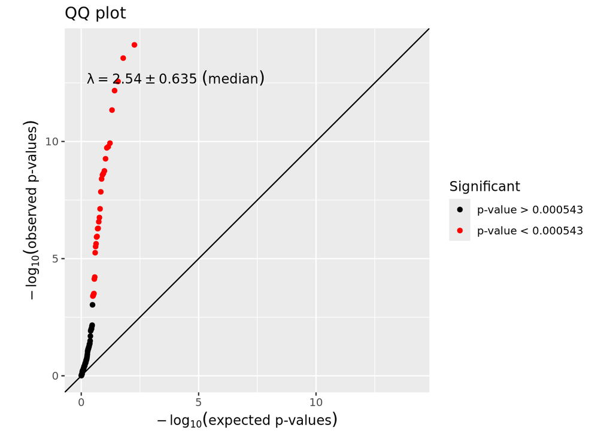

```
>
> $pleural.comp.out
```

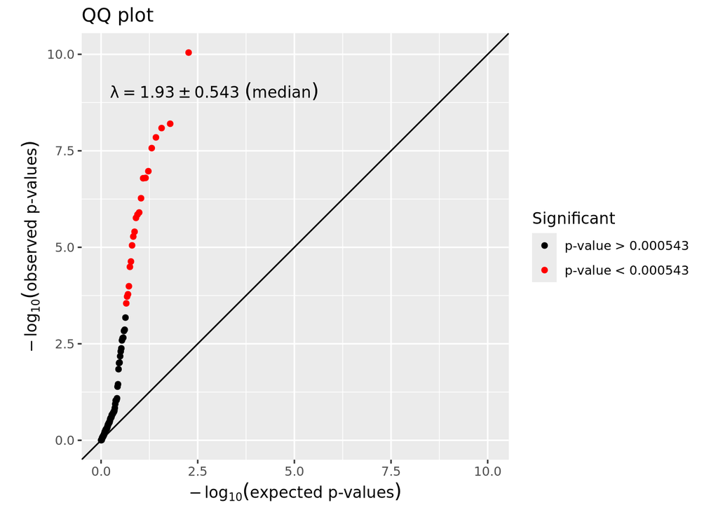

```
>
> $pleural.infect.bi.new
```

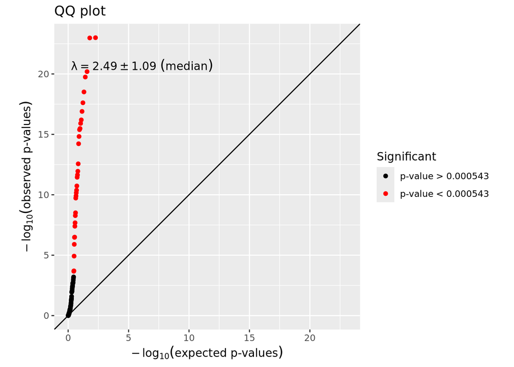

```
>
> $pleural.female
```

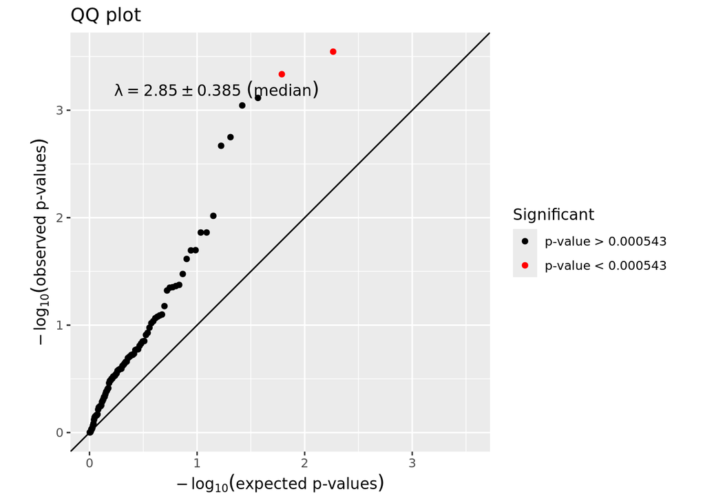

```
>
> $pleural.age
```

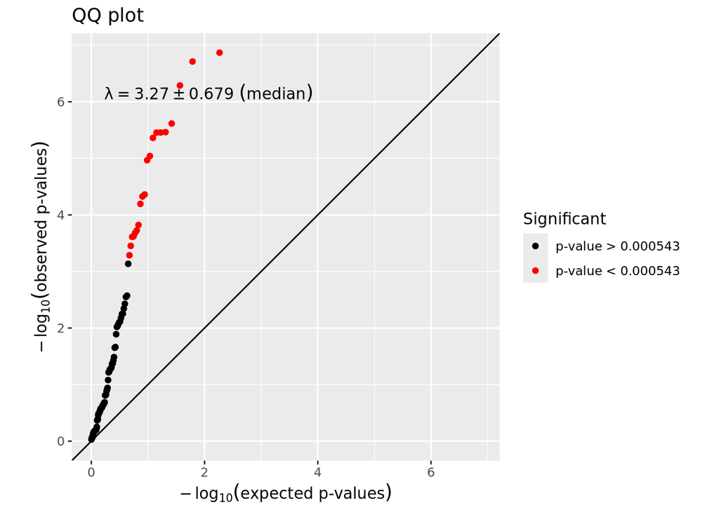

```
>
> $pleural.infect.fct.plate
```

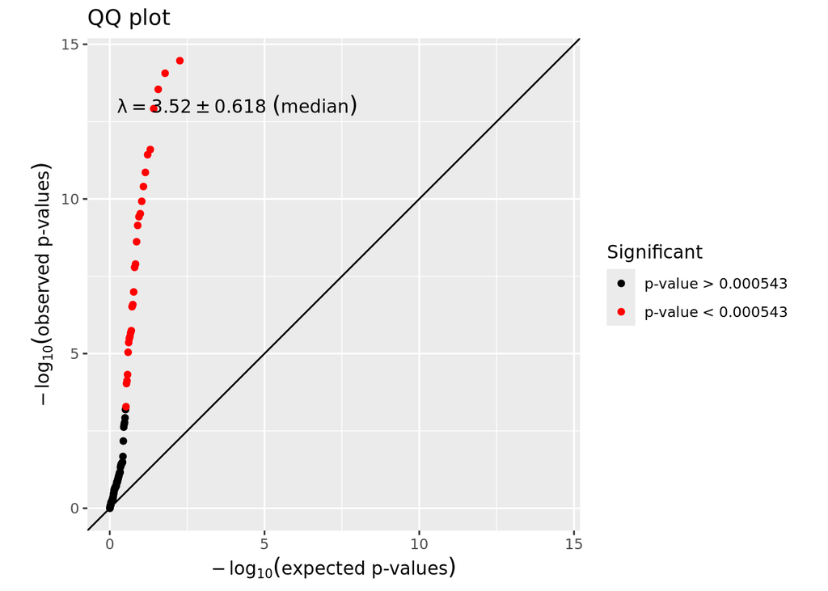

```
>
> $pleural.infect.num.plate
```

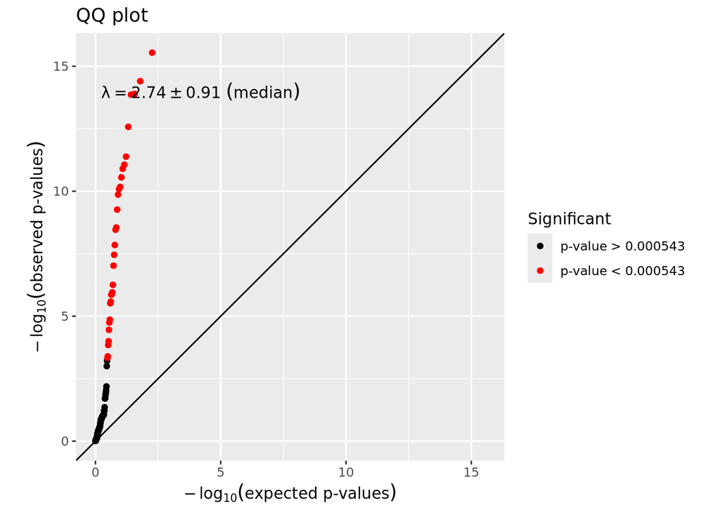

```
>
> $pleural.infect.bi.plate
```

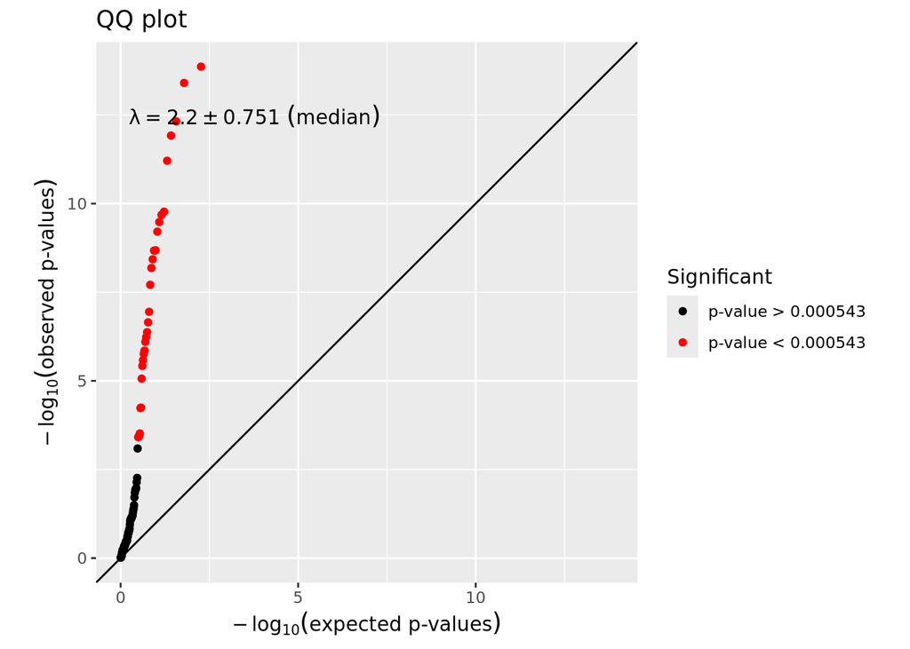

```
>
> $pleural.comp.out.plate
```

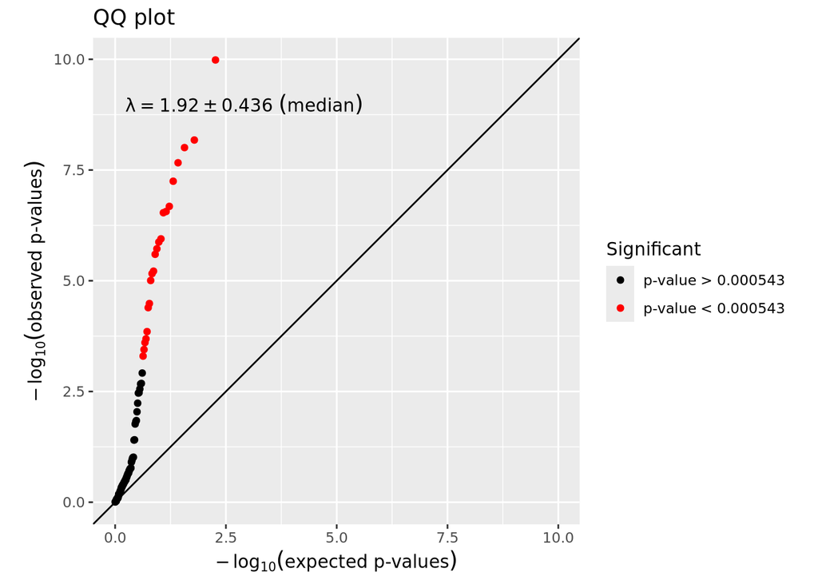

```
>
> $pleural.infect.bi.new.plate
```

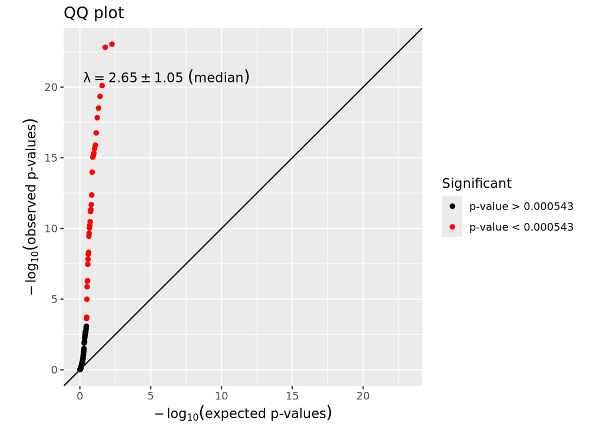

```
>
> $pleural.female.plate
```

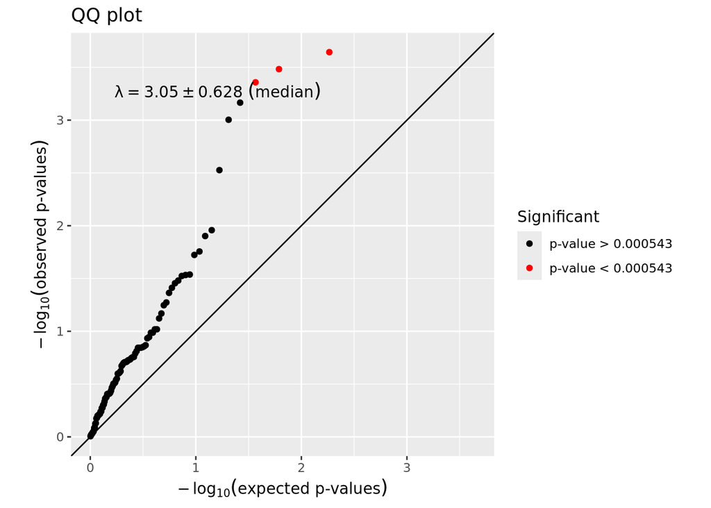

```
>
> $pleural.age.plate
```

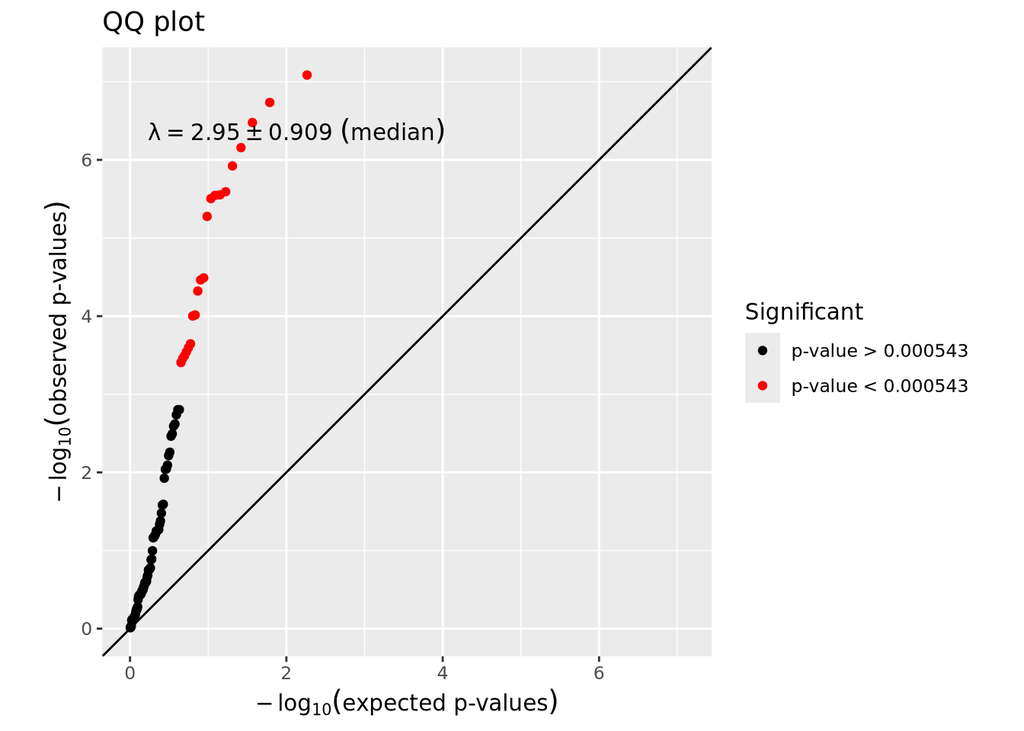

```
>
> $pleural.infect.fct.fulladj
```

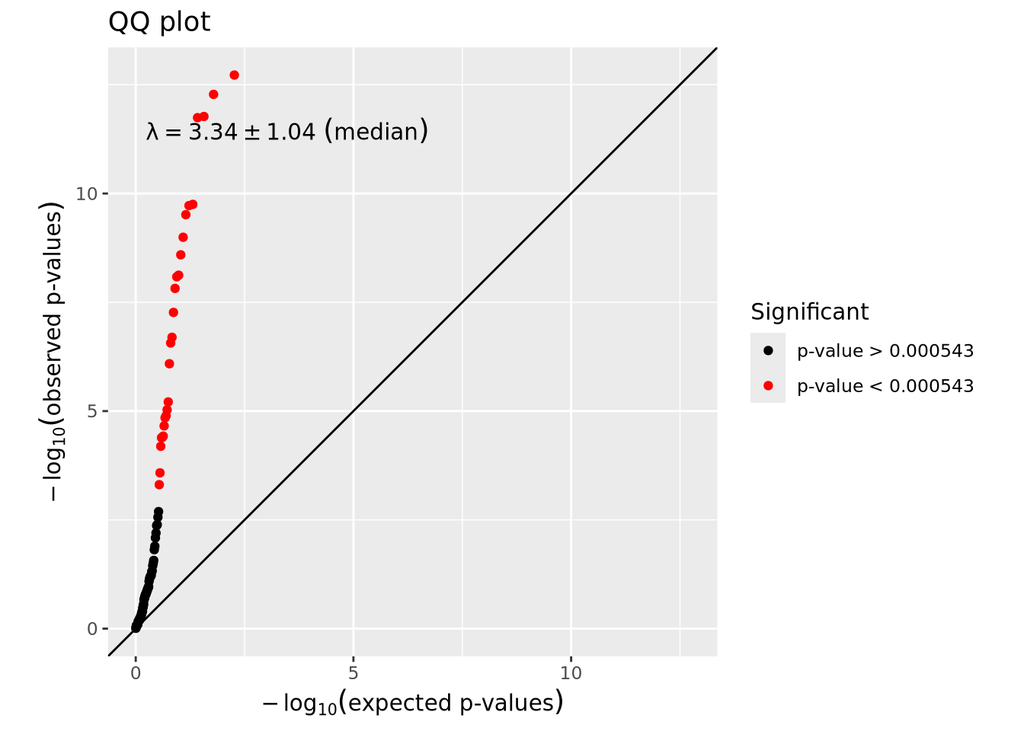

```
>
> $pleural.infect.num.fulladj
```

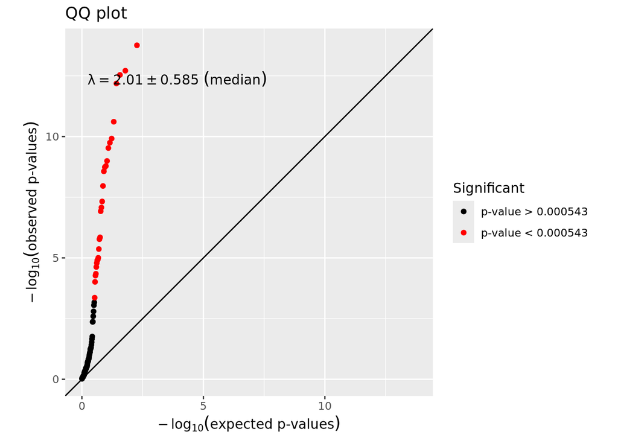

```
>
> $pleural.infect.bi.fulladj
```

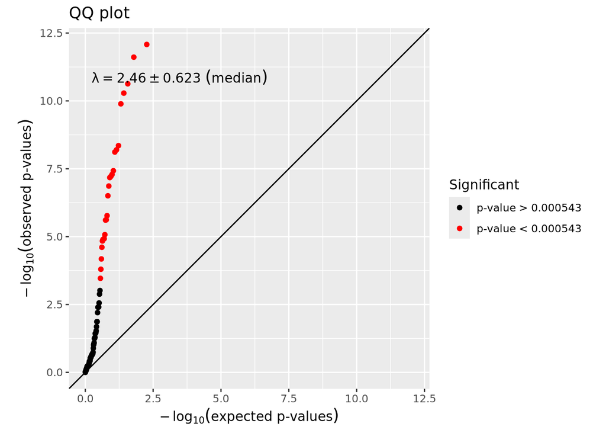

```
>
> $pleural.comp.out.fulladj
```

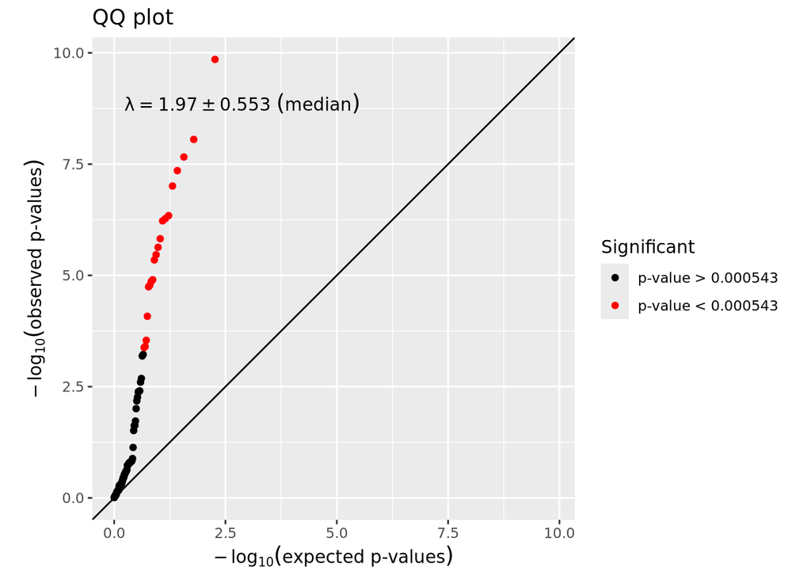

```
>
> $pleural.infect.bi.new.fulladj
```

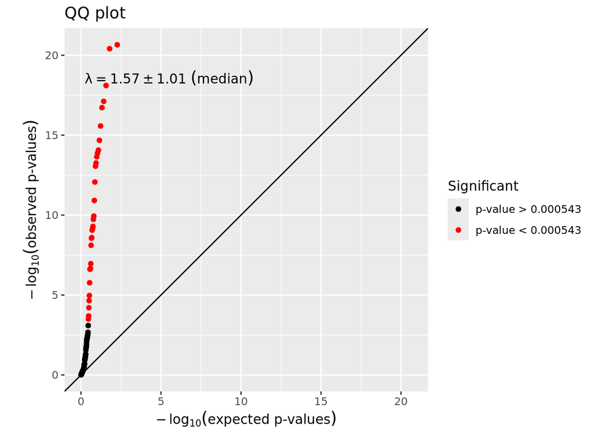